# Time Series Analysis and Its Applications - Exercises

Ewok

May 20, 2016

# Chapter 1

### Brain Activation Plots

The following plots show measures of activation in the brain in terms of blood oxygenation-level dependent signal intensity for five subjects when given periodic brushing on the hand. The signal period is 64 seconds, and the sampling rate is one observation every 2 seconds for 256 seconds. The results were averaged over subjects.

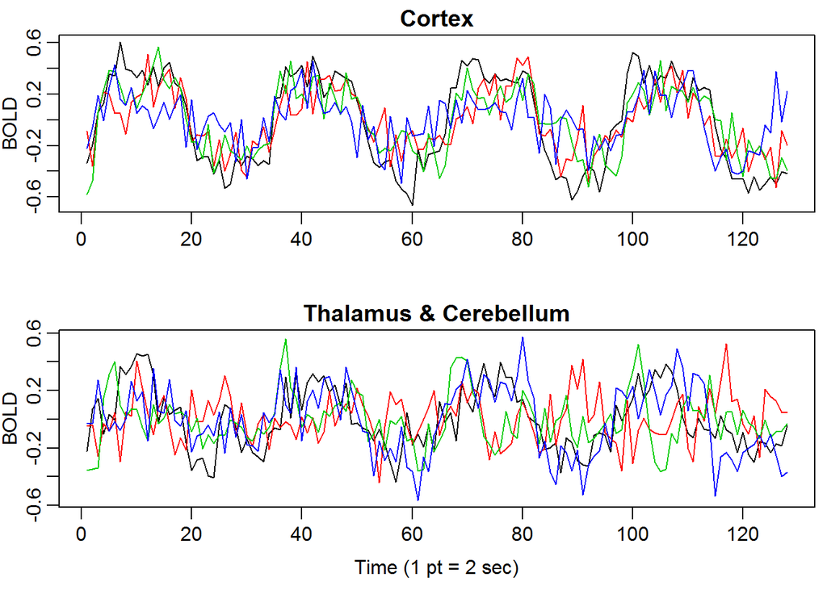

```r
par(mfrow=c(2,1), mar=c(3,2,1,0)+.5, mgp=c(1.6,.6,0))
ts.plot(fmri1[,2:5], col=1:4, ylab="BOLD", xlab="", main="Cortex")
ts.plot(fmri1[,6:9], col=1:4, ylab="BOLD", xlab="", main="Thalamus & Cerebellum")
mtext("Time (1 pt = 2 sec)", side=1, line=2)
```

### Effect of White Noise

The next plots show the effect of increasing additive white Gaussian noise to a cosine wave.

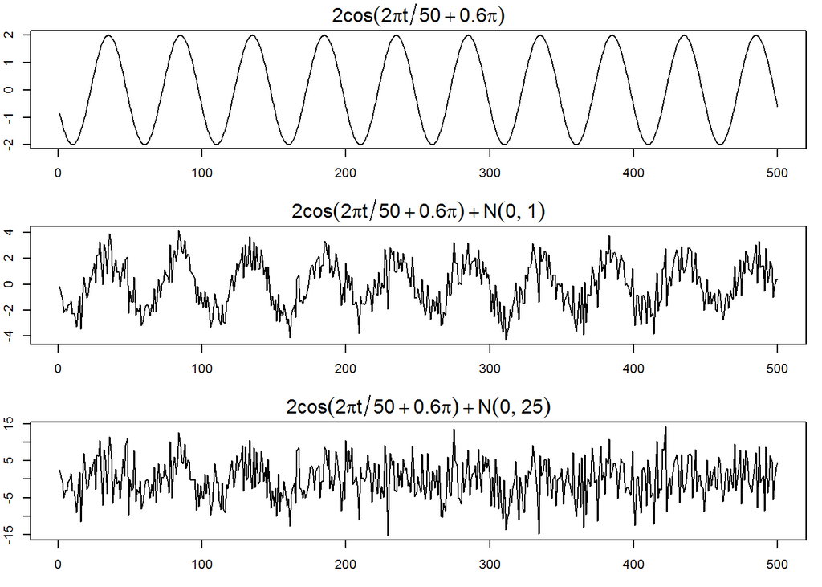

```r
cs = 2*cos(2*pi*1:500/50 + .6*pi); w = rnorm(500,0,1)
par(mfrow=c(3,1), mar=c(3,2,2,1), cex.main=1.5)
plot.ts(cs, main=expression(2*cos(2*pi*t/50+.6*pi)))
plot.ts(cs+w, main=expression(2*cos(2*pi*t/50+.6*pi) + N(0,1)))
plot.ts(cs+5*w, main=expression(2*cos(2*pi*t/50+.6*pi) + N(0,25)))
```

# Chapter 2

### Mortality, Temperature, and Pollution

The following plots show average weekly cardiovascular mortality, temperature, and particulate pollution in Los Angeles County over a 10 year period from 1970 to 1979.

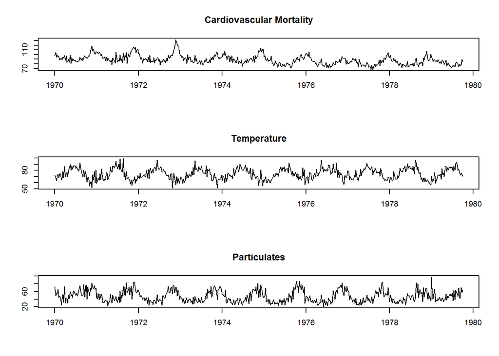

```r
par(mfrow=c(3,1)) # plot the data
plot(cmort, main="Cardiovascular Mortality", xlab="", ylab="")
plot(tempr, main="Temperature", xlab="", ylab="")
plot(part, main="Particulates", xlab="", ylab="")
```

The data is then plotted on a scatterplot matrix to visualize the relations between the three variables. Temperature, which is negatively correlated with mortality, appears to have a quadratic effect on it. Pollution is positivily correlated with mortality.

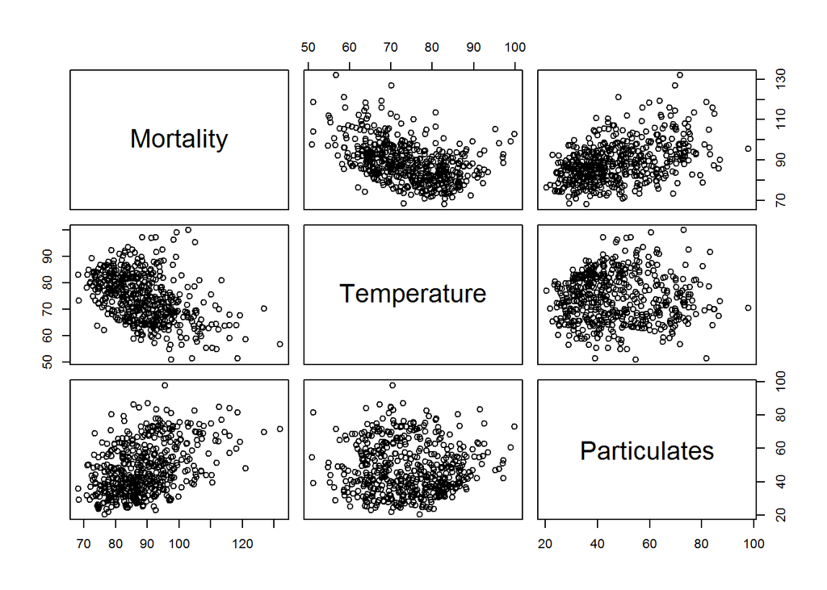

```r
pairs(cbind(Mortality=cmort, Temperature=tempr, Particulates=part))
```

### Smoothing a Time Series

The following shows four different methods to smooth a time series in order to remove white noise. The moving average plot uses the average of the six previous and six future data points. The kernel smoother is a weighted moving average smoother, giving more weight to data points that are closer to the point being estimated. The locally weighted scatterplot smoother (lowess) uses nearest neighbor regression to smooth the plot. Finally, the smoothed spline plot uses polynomial regression to estimate each point.

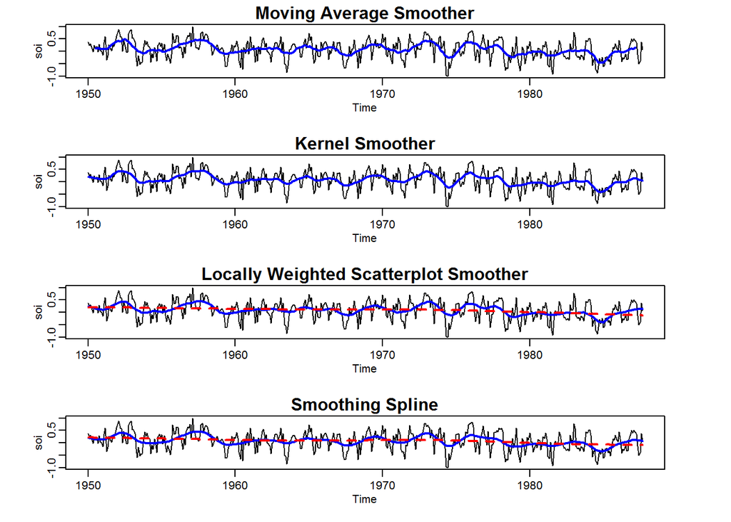

```r
par(mfrow=c(4,1), mar=c(3,4,1,4)+.8, mgp=c(1.6,.6,0), cex.main=1.5)
wgts = c(.5, rep(1,11), .5)/12
soif = filter(soi, sides=2, filter=wgts)
plot(soi, main="Moving Average Smoother")
lines(soif, lwd=2, col=4)
plot(soi, main="Kernel Smoother")
lines(ksmooth(time(soi), soi, "normal", bandwidth=1), lwd=2, col=4)
plot(soi, main="Locally Weighted Scatterplot Smoother")
lines(lowess(soi, f=.05), lwd=2, col=4)
lines(lowess(soi), lty=2, lwd=2, col=2)
plot(soi, main="Smoothing Spline")
lines(smooth.spline(time(soi), soi, spar=.5), lwd=2, col=4)
lines(smooth.spline(time(soi), soi, spar=1), lty=2, lwd=2, col=2)
```